# Manual Chapter2 Walkthrough And Exercises

Luna Liu

2022-04-14

### Set up animint2 package

```r
knitr::opts_chunk$set(echo = TRUE)
library(animint2)
library(graphics)
library(devtools)
library(gistr)
gist_auth()
```

[output not shown]

### Load data

```r
data(WorldBank, package="animint2")
tail(WorldBank)
```

```
##       iso2c  country year fertility.rate life.expectancy population
## 13033    ZW Zimbabwe 2007          3.491        45.79707   12740160
## 13034    ZW Zimbabwe 2008          3.428        47.07061   12784041
## 13035    ZW Zimbabwe 2009          3.360        48.45049   12888918
## 13036    ZW Zimbabwe 2010          3.290        49.86088   13076978
## 13037    ZW Zimbabwe 2011          3.219        51.23644   13358738
## 13038    ZW Zimbabwe 2012             NA              NA   13724317
##       GDP.per.capita.Current.USD 15.to.25.yr.female.literacy iso3c
## 13033                   415.3755                          NA   ZWE
## 13034                   345.4074                          NA   ZWE
## 13035                   475.8538                          NA   ZWE
## 13036                   568.4275                    99.55316   ZWE
## 13037                   722.8377                          NA   ZWE
## 13038                   787.9382                          NA   ZWE
##                                       region capital longitude latitude
## 13033 Sub-Saharan Africa (all income levels)  Harare   31.0672 -17.8312
## 13034 Sub-Saharan Africa (all income levels)  Harare   31.0672 -17.8312
## 13035 Sub-Saharan Africa (all income levels)  Harare   31.0672 -17.8312
## 13036 Sub-Saharan Africa (all income levels)  Harare   31.0672 -17.8312
## 13037 Sub-Saharan Africa (all income levels)  Harare   31.0672 -17.8312
## 13038 Sub-Saharan Africa (all income levels)  Harare   31.0672 -17.8312
##           income lending
## 13033 Low income   Blend
## 13034 Low income   Blend
## 13035 Low income   Blend
## 13036 Low income   Blend
## 13037 Low income   Blend
## 13038 Low income   Blend
```

```r
dim(WorldBank)
```

```
## [1] 11342    15
```

### Life expectancy against fertility rate

```r
WorldBank1975 <- subset(WorldBank, year==1975)
head(WorldBank1975)
```

```
##     iso2c              country year fertility.rate life.expectancy population
## 281    AD              Andorra 1975             NA              NA      30706
## 334    AE United Arab Emirates 1975          6.009        66.18539     532742
## 387    AF          Afghanistan 1975          7.692        37.25712   12551790
## 440    AG  Antigua and Barbuda 1975             NA              NA      69253
## 493    AL              Albania 1975          4.417        68.32583    2426592
## 546    AM              Armenia 1975          2.745        70.52751    2825650
##     GDP.per.capita.Current.USD 15.to.25.yr.female.literacy iso3c
## 281                  7168.3987                          NA   AND
## 334                 27631.8985                    56.27697   ARE
## 387                   188.5521                          NA   AFG
## 440                         NA                          NA   ATG
## 493                         NA                          NA   ALB
## 546                         NA                          NA   ARM
##                                             region          capital longitude
## 281      Europe & Central Asia (all income levels) Andorra la Vella    1.5218
## 334 Middle East & North Africa (all income levels)        Abu Dhabi   54.3705
## 387                                     South Asia            Kabul   69.1761
## 440  Latin America & Caribbean (all income levels)     Saint John's  -61.8456
## 493      Europe & Central Asia (all income levels)           Tirane   19.8172
## 546      Europe & Central Asia (all income levels)          Yerevan    44.509
##     latitude               income        lending
## 281  42.5075 High income: nonOECD Not classified
## 334  24.4764 High income: nonOECD Not classified
## 387  34.5228           Low income            IDA
## 440  17.1175  Upper middle income           IBRD
## 493  41.3317  Upper middle income           IBRD
## 546  40.1596  Lower middle income          Blend
```

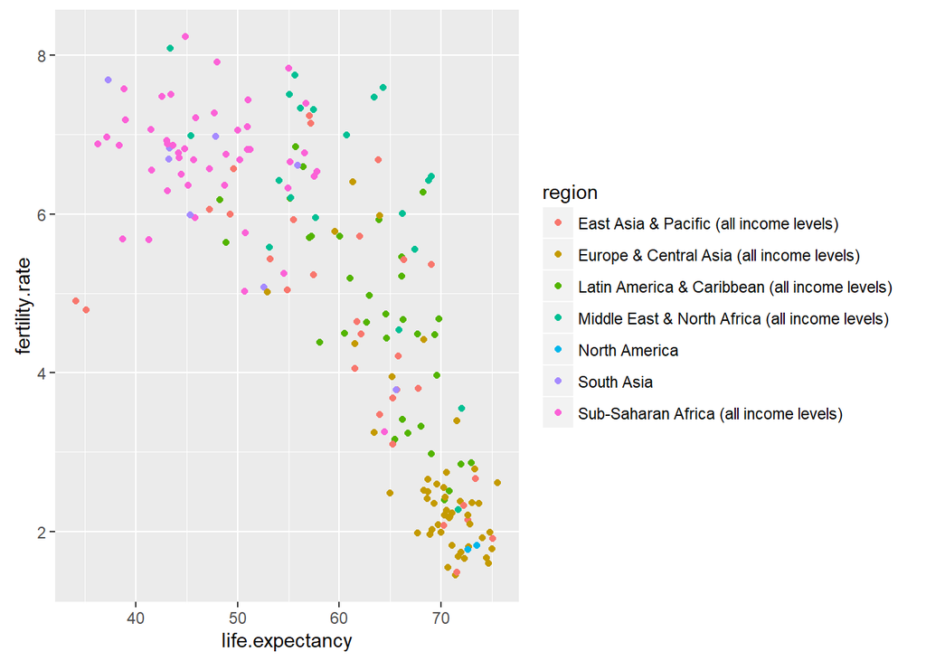

```r
scatter <- ggplot()+
  geom_point(
    mapping=aes(x=life.expectancy, y=fertility.rate, color=region),
    data=WorldBank1975)
scatter
```

```r
animint(scatter)
```

### Multiple geoms

```r
WorldBankBefore1975 <- subset(WorldBank, 1970 <= year & year <= 1975)
two.layers <- scatter+
  geom_path(aes(x=life.expectancy, y=fertility.rate, color=region,
                group=country),
            data=WorldBankBefore1975)
(viz.two.layers <- animint(two.layers))
```

# Exercise in section Multi-layer data visualization (multiple geoms)

Exercise: try changing the region legend to an income legend. Hint: you need to use the same aes(color=income) specification for all geoms. You may want to use scale_color_manual with a sequential color palette, see RColorBrewer::display.brewer.all(type=“seq”) and read the appendix for more details.

```r
scatter.income <- ggplot()+
  geom_point(
    mapping=aes(x=life.expectancy, y=fertility.rate, color=income),
    data=WorldBank1975)
two.layers.income <- scatter.income+
  geom_path(aes(x=life.expectancy, y=fertility.rate, color=income,
                group=country),
            data=WorldBankBefore1975)
(viz.two.layers.income <- animint(two.layers.income))
```

### Add name of countries(three layers)

```r
three.layers <- two.layers+
  geom_text(aes(x=life.expectancy, y=fertility.rate, color=region,
                label=country),
            data=WorldBank1975)
animint(three.layers)
```

### Multi-plot

```r
viz.two.plots <- viz.two.layers
viz.two.plots$timeSeries <- ggplot()+
  geom_line(aes(x=year, y=fertility.rate, color=region, group=country),
            data=WorldBank)
summary(viz.two.plots)
```

```
##            Length Class     Mode
## twolayers  9      gganimint list
## timeSeries 9      gganimint list
```

```r
viz.two.plots
```

# Exercise in section Multi-plot data visualization

Exercise: use animint to create a data viz with three plots, by creating a list with three ggplots. For example, you could add a time series of another data variable such as life.expectancy or population.

```r
viz.three.plots <- viz.two.plots
viz.three.plots$pop <- ggplot()+
  geom_line(aes(x=population, y=fertility.rate, color=region, group=country),
            data=WorldBank)
summary(viz.three.plots)
```

```
##            Length Class     Mode
## twolayers  9      gganimint list
## timeSeries 9      gganimint list
## pop        9      gganimint list
```

```r
viz.three.plots
```

### Different geoms in each panel (aligned axes)

```r
add.x.var <- function(df, x.var){
  data.frame(df, x.var=factor(x.var, c("life expectancy", "year")))
}
(viz.aligned <- animint(
  scatter=ggplot()+
    geom_point(aes(x=life.expectancy, y=fertility.rate, color=region),
               data=add.x.var(WorldBank1975, "life expectancy"))+
    geom_path(aes(x=life.expectancy, y=fertility.rate, color=region,
                  group=country),
              data=add.x.var(WorldBankBefore1975, "life expectancy"))+
    geom_line(aes(x=year, y=fertility.rate, color=region, group=country),
              data=add.x.var(WorldBank, "year"))+
    xlab("")+
    facet_grid(. ~ x.var, scales="free")+
    theme_bw()+
    theme(panel.margin=grid::unit(0, "lines"))
  ))
```

### Same geoms in each panel (compare data subsets)

```r
show.point.list <- list()
show.path.list <- list()
for(show.year in c(1975, 1985, 1995)){
  show.point.list[[paste(show.year)]] <- data.frame(
    show.year, subset(WorldBank, year==show.year))
  show.path.list[[paste(show.year)]] <- data.frame(
    show.year, subset(WorldBank, show.year - 5 <= year & year <= show.year))
}
show.point <- do.call(rbind, show.point.list)
show.path <- do.call(rbind, show.path.list)

viz.panels <- list(
  scatter=ggplot()+
    geom_point(aes(x=life.expectancy, y=fertility.rate, color=region),
               data=show.point)+
    geom_path(aes(x=life.expectancy, y=fertility.rate, color=region,
                  group=country),
              data=show.path)+
    facet_grid(. ~ show.year)+
    theme_bw()+
    theme(panel.margin=grid::unit(0, "lines"))
  )
structure(viz.panels, class="animint")
```

# Exercises at the end

- What are the three main advantages of ggplot2 relative to previous plotting systems such as grid and lattice?
1. Compared to `lattice`, `ggplot2` has fewer limitations on types of plots.
2. Compared to general plotting system, `ggplot2` is easier to include common plot elements.
3. As `ggplots2` requires mapping from data variable to visual properties, it is easier to mapping the sketches into R code.
- What is the purpose of multi-layer graphics?  
  We use multi-layer graphics to display several geom layers/data varialbes in the same plot.
- What are the two different reasons for creating multi-panel graphics? Which of these two types is useful with interactivity?
1. We want to align different but related plots containing different geoms. e.g. Same y-axes but different x-axes.
2. We want to divide same data into several buckets.  
   The first one is more useful with interactivity. Because in first case, different panels usually has aligned axes, so we can compare different geoms.
- Let us define “A < B” to mean that “one B can contain several A.” Which of the following statements is true?  
  ggplot < panel **False: one panel can contains only one plot**  
  panel < ggplot **True**  
  ggplot < animint **True: animint is a fork of ggplot**  
  animint < ggplot **False**  
  layer < panel **True: in the example `Different geoms in each panel (aligned axes)`, the first panel contains both path and point**  
  panel < layer **True: in the example in `Same geoms in each panel (compare data subsets)`, the same layer is divided into three panels**  
  layer < ggplot **True: That’s one feature of ggplot**  
  ggplot < layer **True: Same layer can be divided into differnt ggplots based on some filters**
- In the viz.aligned facets, why is it important to use the scales=“free” argument?  
  Because the x-axes in two different panels have different units. If not free x-axes, two panels will have same scale.
- In viz.aligned we showed a ggplot with a scatterplot panel on the left and a time series panel on the right. Make another version of the data visualization with the time series panel on the left and the scatterplot panel on the right.  
  “In particular, if we wanted to change the order of the panels in the data visualization, we would only need to edit the order of the factor levels in the definition of add.x.var.”

```r
add2.x.var <- function(df, x.var){
  data.frame(df, x.var=factor(x.var, c("year", "life expectancy")))
}
(viz.aligned.switch <- animint(
  scatter=ggplot()+
    geom_point(aes(x=life.expectancy, y=fertility.rate, color=region),
               data=add2.x.var(WorldBank1975, "life expectancy"))+
    geom_path(aes(x=life.expectancy, y=fertility.rate, color=region,
                  group=country),
              data=add2.x.var(WorldBankBefore1975, "life expectancy"))+
    geom_line(aes(x=year, y=fertility.rate, color=region, group=country),
              data=add2.x.var(WorldBank, "year"))+
    xlab("")+
    facet_grid(. ~ x.var, scales="free")+
    theme_bw()+
    theme(panel.margin=grid::unit(0, "lines"))
  ))
```

- In viz.aligned the scatterplot displays fertility rate and life expectancy, but the time series displays only fertility rate. Make another version of the data visualization that shows both time series. Hint: use both horizontal and vertical panels in facet_grid.  
  Sketch of the idea:

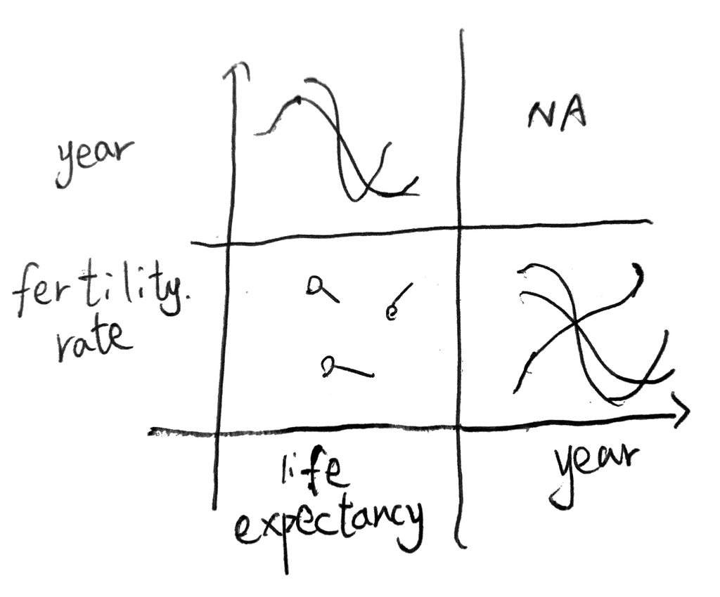

sketch

```r
add.vars <- function(df, x.var, y.var){
  data.frame(df, x.var=factor(x.var, c("life expectancy", "year")), y.var=factor(y.var,c("fertility rate", "year")))
}

(viz.aligned <- animint(
  scatter=ggplot()+
    geom_point(aes(x=life.expectancy, y=fertility.rate, color=region),
               data=add.vars(WorldBank1975, "life expectancy", "fertility rate"))+
    geom_path(aes(x=life.expectancy, y=fertility.rate, color=region,
                  group=country),
              data=add.vars(WorldBankBefore1975, "life expectancy", "fertility rate"))+
    geom_line(aes(x=year, y=fertility.rate, color=region, group=country),
              data=add.vars(WorldBank, "year", "fertility rate"))+
    geom_line(aes(x=life.expectancy, y=year,color=region, group=country),
              data=add.vars(WorldBank,"life expectancy","year"))+
    xlab("")+
    ylab("")+
    facet_grid(y.var~x.var, scales="free")+
    theme_bw()+
    theme(panel.margin=grid::unit(0, "lines"))
  ))
```

- Use aes(size=population) in the scatterplot to show the population of each country. Hint: scale_size_animint(pixel.range=c(5, 10) means that circles with a radius of 5/10 pixels should be used represent the minimum/maximum population.

```r
(viz.aligned.switch <- animint(
  scatter=ggplot()+
    geom_point(aes(x=life.expectancy, y=fertility.rate, color=region, size=population),
    data=WorldBank1975)
 + scale_size_animint(pixel.range=c(5,10))))
```

- Create a multi-panel data visualization that shows each year of the WorldBank data set in a separate panel. What are the limitations of using static graphics to visualize these data?

```r
min(WorldBank$year)
```

```
## [1] 1960
```

```r
max(WorldBank$year)
```

```
## [1] 2012
```

```r
#min=1960 max =2012
show.point.list <- list()
years <- levels(as.factor(WorldBank$year))
for(show.year in years){
  show.point.list[[paste(show.year)]] <- data.frame(
    show.year, subset(WorldBank, year==show.year))
}
show.point <- do.call(rbind, show.point.list)

viz.panels.all <- list(
  scatter=ggplot()+
    geom_point(aes(x=life.expectancy, y=fertility.rate, color=region),
               data=show.point)+
    facet_grid(. ~ show.year)+
    theme_bw()+
    theme(panel.margin=grid::unit(0, "lines"))
  )

#Please run
#devtools::install_github('rOpenSci/gistr')before using this function
animint2gist(viz.panels.all, description = "My animint plot", browse = TRUE)
```

```
## <gist>64b127c5d0b96f4594c96180e6ea767b
##   URL: https://gist.github.com/64b127c5d0b96f4594c96180e6ea767b
##   Description: My animint plot
##   Public: TRUE
##   Created/Edited: 2022-04-15T00:21:44Z / 2022-04-15T00:21:44Z
##   Files: animint.js, d3.v3.js, geom1_point_scatter_chunk1.tsv, index.html, jquery-1.11.3.min.js, plot.json, scripts.html, selectize.css, selectize.min.js
##   Truncated?: FALSE, FALSE, TRUE, TRUE, TRUE, TRUE, TRUE, TRUE, TRUE
```

- Create viz.aligned using a plotting system that is not based on the grammar of graphics. For example, you can use functions from the graphics package in R (plot, points, lines, etc), or matplotlib in Python. What are some advantages of ggplot2 and animint?

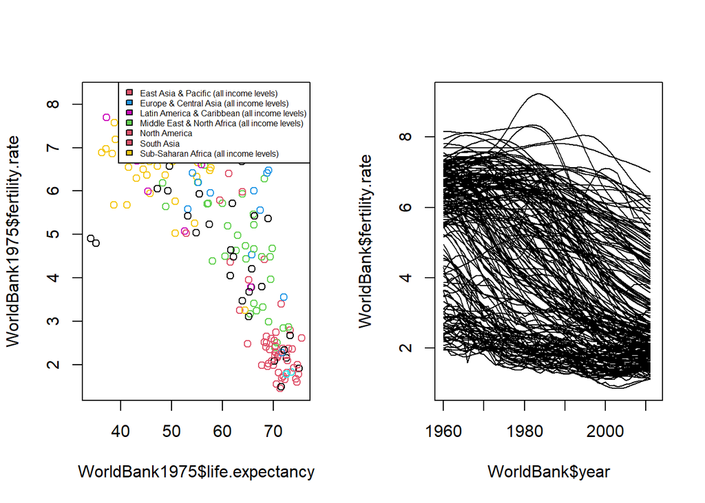

```r
par(mfrow=c(1,2))
plot(x=WorldBank1975$life.expectancy, y=WorldBank1975$fertility.rate,col=WorldBank1975$region)

legend("topright",cex = 0.5, legend=c(levels(as.factor(WorldBank$region))),
       fill=WorldBank1975$region)

plot(x=WorldBank$year,y=WorldBank$fertility.rate,type='l')
```

When we don’t use the grammar of graphics, each component of the plot is separate. For example, we cannot add scatter points and lines as layers to the same graph, we have to make two plots and plot them separately. We also have to create a legend on top of this. But when it comes to packages using grammar of graphics, as `ggplot2` and `animint`, we have a single canvas and keep adding layers to it.